# Generating random data and probability distributions

Oscar Rodriguez de Rivera

In statistics it is useful to be able to generate random data. This worksheet will lead you through how to take random samples from a vector of observations and also how to generate random samples from named probability distributions that we have encountered.

### Introduction

The function sample() in R can produce a random sample of discrete random variables. Suppose we want to sample from the vector x. We can type:

```r
x <- c(0,1)
sample(x,10,replace=TRUE) #with replacement
```

```
##  [1] 1 0 0 1 0 0 1 0 1 0
```

Alternatively we could have typed:

```r
sample(0:1,10,replace=TRUE) #with replacement
```

```
##  [1] 1 1 1 0 1 1 0 1 0 0
```

We note that we have told R to sample with replacement. If instead we want to sample without replacement:

```r
sample(0:11,10,replace=FALSE) #without replacement
```

```
##  [1]  8  9 10  7  1  6  3 11  0  4
```

- **Exercise 1.1**

Using R toss a coin 100 times. How many heads did you get?

**Solution:**

The first command above can be use as a random sample when tossing a coin 100 times where 1 is for heads and 0 is for tails. Don’t be surprised to get more or less heads than below!

```r
sum(sample(0:1,100,replace=TRUE))
```

```
## [1] 51
```

- **Exercise 1.2**

Using R roll a die 10 times. How many 5s did you get?

**Solution:**

```r
x<-sample(1:6,10,replace=TRUE)
x
```

```
##  [1] 4 4 2 3 3 5 1 6 4 2
```

```r
length(x[x==5])
```

```
## [1] 1
```

### Statistical Distributions

| Distribution | R function | Arguments | Example using the “r” prefix |
| --- | --- | --- | --- |
| Binomial | binom | size, probability | rbinom(n, size, prob) |
| Chi-squared | chisq | df (degrees of freedom) | rchisq(n, df) |
| Exponential | exp | rate | rexp(n, rate=1) |
| F | f | df1, df2, | rf(n, df1, df2) |
| Normal | norm | mean, sd | rnorm(n, mean=0, sd=1) |
| Poisson | pois | lambda | rpois(n, lambda) |
| Student’s t | t | df, ncp | rt(n, df) |
| Uniform | unif | min, max | runif(n, min=0, max=1) |

R offers built in functions for many probability density functions. The table above gives some examples of distributions in R together with the main arguments which are needed to use these functions. The functions below can be used in four different ways, with a different prefix

- “d” for probability density function;
- “r” for random numbers generation;
- “p” for the cumulative distribution function;
- “q” for the quantiles.

Remember that each distribution is characterised by **different parameters** and hence the arguments will be different e.g. the `norm` function requires that you specify the **sample size**, the **mean** and the **standard deviation** whereas the `pois` requires that you specify the **sample size** and the parameter **lambda**.

- **Exercise 2.1** What do each of the following commands compute?
1. rexp(4,rate=2)
2. qf(0.05, 6, 7, lower.tail = FALSE)
3. pt(1,3)
4. dnorm(1)
5. dunif(x=1, min=0, max=3)
6. punif(.05, min=0, max=3)
7. punif(1.5, min=0, max=3)

### Simulation

#### The Law of Large Numbers

The weak law of large numbers states that if $X1, . . . , Xn$ are i.i.d. random variables with population mean $\mu$, the $\bar{X}=\frac{1}{n}\sum_{i=1}^{n}X_{i}\rightarrow \mu$ as $n \rightarrow \infty$. For the population proportion, replace $\mu$ for $\pi$.

Let us think about how to demonstrate the law of large numbers for the population proportion. First let us simulate the outcome from 500 Bernoulli trials, with parameter $p$ = 0.5:

```r
Bernoulli_trials<-rbinom(500,1,.5) #500 independent Bernoulli trials
```

Now let us compute the cumulative sum of the vector where we have stored these outcomes:

```r
cumsum1<-cumsum(Bernoulli_trials) #cumulative sum
```

We now want to compute the mean of each element of the cumulative sum vector.

```r
relfreq2<-cumsum1/(1:500) #relative frequency
```

We can now plot this vector and also include a reference line of the population proportion:

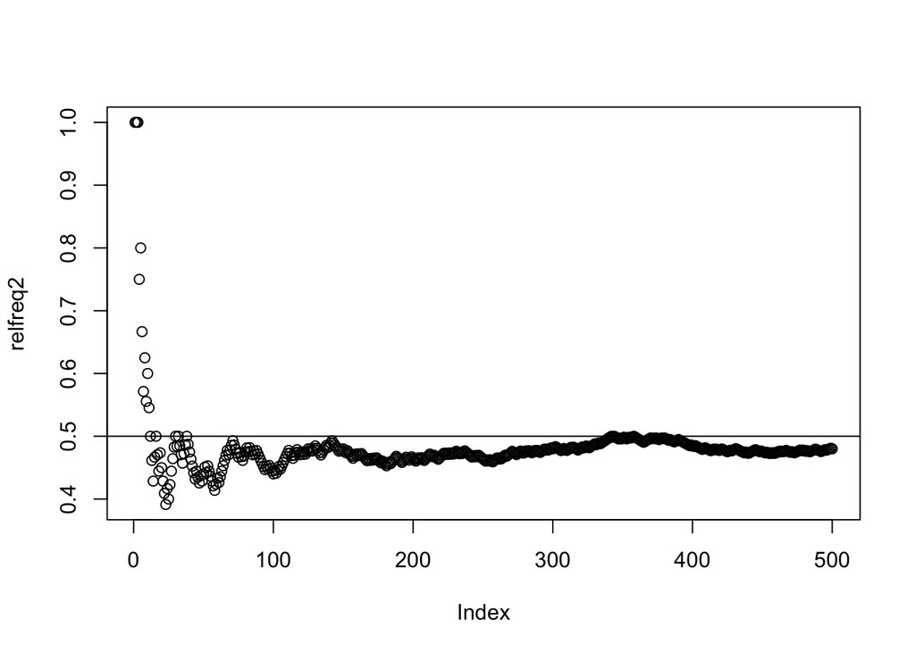

```r
plot(relfreq2)
abline(0.5,0)
```

- **Exercise 3.1**  
  Use R to produce a visual representation of the Law of Large numbers for the population mean. You can simulate your values from any probability distribution you wish.

#### The Central Limit Theorem

Many statistical techniques like interval estimation and hypothesis testing are based on the assumption that the observed data are normally distributed. We have seen in lectures, how we can use the Central Limit Theorem (CLT) to obtain the sampling distribution of the sample mean $\bar{X}$. The CLT states that for a random sample $X_1, X_2, . . . , X_n$ from a distribution with mean $\mu$ and variance $\sigma^2$, then $\bar{X} \sim N(\mu, \sigma^2/n)$ (approximately) when the sample size $n$ is large (at least 30).

Assume that there is a random sample $X_1, X_2, . . . , X_n$ from the uniform U$[0,1]$ distribution. We want to derive the sampling distribution of the sample mean $\bar{X}$ when the sample size n changes. We want to generate 500 random samples of the U$[0,1]$, every time with a different sample size $n$. To do this we will need to use a for `loop` to repeat sampling:

```r
xbar<-c()
for(i in 1:500) {xbar[i] = mean(runif(10))}
```

- **Exercise 3.2**

Answer the following questions about the code above:

1. How many times does the for loop run the above code?

**Solution:** It runs 500 times. Here we have 500 repetitions of mean(runif(10))

2. Why is xbar<-c() needed?

**Solution:** xbar will hold the sample mean values for each sample

3. How many numbers from the uniform distribution did we generate?

**Solution:** At every iteration 10 random numbers from the Uniform(0,1) were generated.

- **Exercise 3.3**

Suppose now that we want to repeat the above, that is to study how the uniform U[0,1] distribution approximates the standard Normal distribution when n = 5, 10, 20, 50. Nested for loops can be used in the following way:

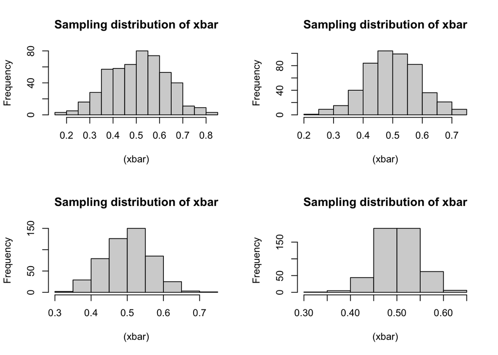

```r
par(mfrow=c(2,2))
m=500; a=0; b=1
for (j in 1: length(n<-c(5,10,20,50)))
{
xbar<-c()
     for (i in 1:m) {xbar[i]<-mean(runif(n[j],a,b))}
hist((xbar),main="Sampling distribution of xbar")
}
```

Running the above code, what do you observe for the shape of the sampling distribution as n increases?

**Solution:** We observe that the approximation of the Normal distribution improves as the sample size n increases.

- **Exercise 3.4**

We can amend the above code to write a function which returns the sampling distribution of $\bar{X}$ for any values of $m$, $n$, $a$ and $b$:

```r
Xbar_Unif_Sampling<-function(m,n,a,b)
 {
   par(mfrow=c(2,2))
   for (j in 1:length(n))
   {
     xbar<-c()
     for (i in 1:m) {xbar[i]<-mean(runif(n[j],a,b))}
     hist((xbar),main="Sampling distribution of xbar")
   }
  }
```

Use this function for values of $m = 1000, n = (50,100,200,500), a = −5, b = 5$.

- **Exercise 3.4**
1. Generate random sample of size 100 from the Uniform[-15,15] distribution. Find the minimum and maximum values from the generated data.

**Solution:**

```r
x<-runif(100,-15,15)
max(x);min(x)
```

```
## [1] 14.75045
```

```
## [1] -14.71888
```

2. For the above random sample, find how many numbers are negative using a for loop and an if statement.

**Solution:**

```r
p<-0
      for (i in 1:100)
      {
   if (x[i]<0) p<-p+1
    }
#You can check the value of p at the console:
p
```

```
## [1] 52
```

3. Amend the above code to write a function which works for any Uniform[a,b] and any sample size n.